# PALS0045 Secondary Data Analysis

Author: Anonymous

Date: 11/29/2020

**word count (excl. code chunks & References): 850**

##### We will investigate whether people’s need-to-belong and narcissism predict their political affiliation.

##### Further, does the latter predict wellbeing?

## Sample Descriptive Statistics

Let’s first compute some descriptive statistics on respondents’ demographics (sex/age/education/residence).

```r
### Loading necessary libraries and the dataset ###
library(tidyverse)
library(ez)
library(broom)

# package necessary to compute all possible pairwise comparison (post-hoc) t-tests, applying a Bonferroni correction to p-values
# install.packages('emmeans')
library(emmeans)

# Package for nicer inline visualisation of dataframes
# install.packages('DT')
library(DT)
```

```r
# loading data
orig_data <- read_csv('courseworkdata.csv')
# keeping relevant data/variables only

# Note: we do not drop rows with NA values in the sex,age,edu and place2 variables because this would lead to the deletion of 1000 rows, which is a high number of further exclusion (i.e., this would delete rows that have values in our variables/columns of interest  but that have no value in sex/age/edu/place2). It is not harmful to do so, since these variables won't be put into our statistical models, and are used only for the descriptive statistics of the sample.

data <- orig_data %>% select(ID, politics, party, belong_1:belong_10, belnow, NPI1:NPI13, swb_1:swb_6, sex, age, edu, place2) %>% drop_na(-c(sex,age,edu,place2))
```

```r
### Introduction & Descriptive Statistics on the sample ###

# table summarising proportion (%) of each sex (1 = Male, 2 = Female, 3 =  Other)
sample_sex <- data %>% group_by(sex) %>% summarise(n_individuals = n(),
                                                   perct = round((100 * n_individuals / 3422),2)
                                                   )
```

```r
# Note: 3422 = n of rows in 'data', i.e. total n of respondents

# Visualisation of the table
datatable(sample_sex,
          rownames = FALSE,
          colnames = c('Number of Individuals', 'Proportion (%)'),
          caption = htmltools::tags$caption(style ='caption-side: bottom; text-align: center;',
                                            'TABLE 1 - ',
                                            htmltools::em('Sample Demographics (sex)')
                                            )
          )
```

|  | Number of Individuals | Proportion (%) |
| --- | --- | --- |
| 1 | 860 | 25.13 |
| 2 | 2475 | 72.33 |
| 3 | 56 | 1.64 |
|  | 31 | 0.91 |

```r
# table summarising mean and sd of the sample's age
# Note: we need to remove rows/observations with NA in age to compute the statistics
sample_age <- data %>% summarise(mean_age = round(mean(age, na.rm = TRUE),2),
                                 mean_sd = round(sd(age, na.rm = TRUE), 2)
                                 )

# Visualisation of the table
datatable(sample_age,
          rownames = FALSE,
          colnames = c('Mean of Age (year)', 'Standard Deviation of Age (year)'),
          caption = htmltools::tags$caption(style ='caption-side: bottom; text-align: center;',
                                            'TABLE 2 - ',
                                            htmltools::em('Sample Demographics (age)')
                                            )
          )
```

| Mean of Age (year) | Standard Deviation of Age (year) |
| --- | --- |
| 21.12 | 4.88 |

```r
# table summarising percentage (%) of each educational level
sample_edu <- data %>% group_by(edu) %>% summarise(n_individuals = n(),
                                                   perct = round(100 * (n_individuals / 3422),2)
                                                   )  # 3422 = n of rows in 'data', i.e. total n of respondents
```

```r
# Visualisation of the table
datatable(sample_edu,
          rownames = FALSE,
          colnames = c('Number of Individuals', 'Proportion (%)'),
          caption = htmltools::tags$caption(style ='caption-side: bottom; text-align: center;',
                                            'TABLE 3 - ',
                                            htmltools::em('Sample Demographics (Education)')
                                            )
          )
```

|  | Number of Individuals | Proportion (%) |
| --- | --- | --- |
| 1 | 72 | 2.1 |
| 2 | 2713 | 79.28 |
| 3 | 46 | 1.34 |
| 4 | 204 | 5.96 |
| 5 | 143 | 4.18 |
| 8 | 147 | 4.3 |
| 9 | 64 | 1.87 |
|  | 33 | 0.96 |

```r
# table summarising proportion (%) of respondents residing in the US (1) and Other (2)
sample_localisation <- data %>% group_by(place2) %>% summarise(n_individuals = n(),
                                                               perct = round((100 * (n_individuals / 3422)),2)
                                                               ) # 3422 = n of rows in 'data', i.e. total n of respondents
```

```r
# Visualisation of the table
datatable(sample_localisation,
          rownames = FALSE,
          colnames = c('Number of Individuals', 'Proportion (%)'),
          caption = htmltools::tags$caption(style ='caption-side: bottom; text-align: center;',
                                            'TABLE 4 - ',
                                            htmltools::em('Sample Demographics (Residence)')
                                            )
          )
```

|  | Number of Individuals | Proportion (%) |
| --- | --- | --- |
| 1 | 2967 | 86.7 |
| 2 | 418 | 12.22 |
|  | 37 | 1.08 |

```r
# getting rid of variables used for describing the sample
data <- data %>% select(-sex) %>% select(-age) %>% select(-edu) %>% select(-place2)

# our variables of interest: politics, party, belong1:belong10, belnow, NPI1:NPI13, swv_1:swb_6
datatable(data=data, rownames = FALSE)
```

| ID | politics | party | belong_1 | belong_2 | belong_3 | belong_4 | belong_5 | belong_6 | belong_7 | belong_8 | belong_9 | belong_10 | belnow | NPI1 | NPI2 | NPI3 | NPI4 | NPI5 | NPI6 | NPI7 | NPI8 | NPI9 | NPI10 | NPI11 | NPI12 | NPI13 | swb_1 | swb_2 | swb_3 | … |
| --- | --- | --- | --- | --- | --- | --- | --- | --- | --- | --- | --- | --- | --- | --- | --- | --- | --- | --- | --- | --- | --- | --- | --- | --- | --- | --- | --- | --- | --- | --- |
| 1 | 3 | 3 | 4 | 3 | 4 | 3 | 3 | 3 | 4 | 3 | 2 | 3 | 3 | 2 | 1 | 1 | 1 | 2 | 2 | 2 | 2 | 1 | 1 | 1 | 2 | 1 | 4 | 4 | 4 | … |
| 2 | 5 | 5 | 4 | 4 | 4 | 4 | 4 | 4 | 4 | 4 | 4 | 4 | 3 | 2 | 1 | 1 | 1 | 1 | 2 | 2 | 1 | 1 | 1 | 1 | 2 | 2 | 3 | 6 | 4 | … |
| 3 | 3 | 2 | 2 | 3 | 5 | 3 | 4 | 3 | 2 | 5 | 4 | 5 | 3 | 2 | 1 | 1 | 2 | 1 | 2 | 2 | 1 | 1 | 2 | 1 | 2 | 2 | 4 | 7 | 4 | … |
| 4 | 2 | 1 | 2 | 4 | 2 | 5 | 4 | 3 | 1 | 3 | 5 | 4 | 4 | 1 | 1 | 1 | 2 | 2 | 2 | 2 | 2 | 1 | 2 | 1 | 2 | 1 | 6 | 6 | 6 | … |
| 5 | 8 | 8 | 2 | 5 | 2 | 4 | 4 | 1 | 5 | 5 | 4 | 5 | 2 | 1 | 1 | 1 | 2 | 1 | 2 | 1 | 1 | 2 | 2 | 1 | 2 | 2 | 2 | 2 | 1 | … |
| 6 | 5 | 4 | 4 | 4 | 4 | 3 | 4 | 2 | 4 | 3 | 2 | 4 | 4 | 2 | 2 | 2 | 2 | 1 | 2 | 2 | 2 | 1 | 2 | 2 | 2 | 1 | 7 | 7 | 6 | … |
| 7 | 5 | 6 | 3 | 4 | 2 | 4 | 4 | 3 | 2 | 4 | 3 | 4 | 4 | 2 | 1 | 2 | 2 | 1 | 2 | 2 | 1 | 2 | 2 | 1 | 2 | 2 | 6 | 5 | 6 | … |
| 8 | 6 | 5 | 4 | 1 | 5 | 4 | 1 | 2 | 2 | 5 | 3 | 2 | 5 | 1 | 1 | 2 | 2 | 2 | 2 | 2 | 1 | 1 | 2 | 1 | 1 | 2 | 6 | 5 | 7 | … |
| 9 | 8 | 2 | 3 | 3 | 3 | 3 | 3 | 3 | 3 | 3 | 3 | 3 | 5 | 1 | 2 | 1 | 1 | 2 | 1 | 1 | 1 | 2 | 2 | 1 | 1 | 1 | 7 | 6 | 7 | … |
| 10 | 4 | 3 | 3 | 4 | 2 | 5 | 4 | 4 | 2 | 3 | 4 | 5 | 3 | 1 | 2 | 2 | 1 | 2 | 1 | 2 | 2 | 1 | 2 | 1 | 2 | 1 | 5 | 6 | 6 | … |

[output cut: 3412 more lines]

## Part 1

> Our first research question is the following: are need to belong and narcissism related to political affiliation? In other words, do one’s need to belong and/or narcissism predict one’s political affiliation?

-**Hypotheses & Model**

We hypothesise that there will be a difference in political affiliation ‘mean’ scores between the levels of need_to_belong and narcissism variables; our alternative, non-directional hypothesis is that our 6 groups (groups created at STEP 2) will differ in the political affiliation mean scores that they get. We base our hypothesis on previous research, as reviewed in the preregistration.

We will conduct a two-way between-subjects ANOVA since we have two categorical independent variables (need-to-belong and narcissism levels) and one numeric dependent variable (political affiliation mean score).

We are testing 3 null hypotheses in a two-way ANOVA:

```
-There is no overall difference between levels of 'need to belong'

-There is no overall difference between levels of 'narcissism'

-The difference between levels of 'need to belong' doesn't depend on the levels of 'narcissism' (+vice-versa), i.e. no interaction effect
```

We will reject the null hypotheses if p<.05.

-**Recoding**

```r
### STEP 1 - Preprocessing on the original dataset ###

# creating our numerical DV: political_affiliation (mean of 'politics' and 'party' scores)
data1 <- data %>% mutate(political_affiliation_num = (politics + party) / 2) %>% select(-politics) %>% select(-party)
```

```r
# reverse-coding some belong items before creating need_to_belong_num  (= numerical value associated with the need to belong)
data1 <- data1 %>% mutate(belong_1 = recode(belong_1, '5'=1, '4'=2, '3'=3, '2'=4, '1'=5),
                          belong_3 = recode(belong_3, '5'=1, '4'=2, '3'=3, '2'=4, '1'=5),
                          belong_7 = recode(belong_7, '5'=1, '4'=2, '3'=3, '2'=4, '1'=5),
                          belnow = recode(belnow, '5'=1, '4'=2, '3'=3, '2'=4, '1'=5)
)
```

```r
# creating need_to_belong_num (numeric score, i.e. mean of belong items, on the basis of which need-to-belong levels will be created)
data1 <- data1 %>% mutate(sum_belongs = belong_1+belong_2+belong_3+belong_4+belong_5+belong_6+belong_7+belong_8+belong_9+belong_10+belnow, need_to_belong_num = sum_belongs/11) %>% select(-(belong_1:belong_10)) %>% select(-belnow) %>% select(-sum_belongs)
```

```r
# reverse-coding some narcissism NPI items before creating narcissism_num
data1 <- data1 %>% mutate(NPI1 = recode(NPI1, '1'=2, '2'=1),
                          NPI3 = recode(NPI3, '1'=2, '2'=1),
                          NPI4 = recode(NPI4, '1'=2, '2'=1),
                          NPI6 = recode(NPI6, '1'=2, '2'=1),
                          NPI7 = recode(NPI7, '1'=2, '2'=1),
                          NPI10 = recode(NPI10, '1'=2, '2'=1),
                          NPI12 = recode(NPI12, '1'=2, '2'=1),
                          NPI13 = recode(NPI13, '1'=2, '2'=1)
)
```

```r
# creating narcissism_num (numeric score, i.e., mean of narcissism items, on the basis of which narcissism levels will be created)
data1 <- data1 %>% mutate(narcissism_num = (NPI1+NPI2+NPI3+NPI4+NPI5+NPI6+NPI7+NPI8+NPI9+NPI10+NPI11+NPI12+NPI13)/13) %>% select(-(NPI1:NPI13))
```

```r
### STEP 2 - Creating Groups (the levels of our two categorical IVs) ###

# We use case_when() (extension of ifelse()) source: https://dplyr.tidyverse.org/reference/case_when.html
# We use between() base function: inclusive on left- and right-hand side
# Source:https://stackoverflow.com/questions/56446186/r-dplyrcase-when-in-3539-only-selects-integers-such-as-35-0-but-not-valu

# creating categorical need-to-belong levels
data1 <- data1 %>% mutate(need_to_belong = case_when(
  between(need_to_belong_num, 1, 2.5) ~ 'low need to belong',
  between(need_to_belong_num, 2.51, 3.49) ~ 'moderate need to belong',
  between(need_to_belong_num, 3.5, 5) ~ 'high need to belong')
)
```

```r
# creating categorical narcissism levels
data1 <- data1 %>% mutate(narcissism = case_when(
  between(narcissism_num, 1, 1.5) ~ 'not narcissistic',
  between(narcissism_num, 1.51, 2) ~ 'narcissistic')
)
```

```r
### STEP 3 - Dropping some variables/columns ###

# getting rid of temporary variables we used to create our levels of IV1 (need_to_belong) and IV2 (narcissism)
data1 <- data1 %>% select(-need_to_belong_num) %>% select(-narcissism_num)
```

```r
# creating the dataset we will use for our first research question only
data_RQ1 <- data1 %>% select(-(swb_1:swb_6))

# Visualisation of the dataframe relevant to our Research Question 1
datatable(data_RQ1,
          rownames = FALSE,
          colnames = c('ID', 'Political Affiliation Numeric Score', 'Need to Belong Level', 'Narcissism Level'),
          caption = htmltools::tags$caption(style ='caption-side: bottom; text-align: center;',
                                            'TABLE 5 - ',
                                            htmltools::em('Dataframe for Research Question 1')
                                            )
          )
```

| ID | Political Affiliation Numeric Score | Need to Belong Level | Narcissism Level |
| --- | --- | --- | --- |
| 1 | 3 | moderate need to belong | not narcissistic |
| 2 | 5 | moderate need to belong | not narcissistic |
| 3 | 2.5 | high need to belong | not narcissistic |
| 4 | 1.5 | high need to belong | not narcissistic |
| 5 | 8 | high need to belong | not narcissistic |
| 6 | 4.5 | moderate need to belong | not narcissistic |
| 7 | 5.5 | high need to belong | not narcissistic |
| 8 | 5.5 | low need to belong | not narcissistic |
| 9 | 5 | moderate need to belong | narcissistic |
| 10 | 3.5 | high need to belong | narcissistic |

[output cut: 3412 more lines]

```r
# count of our 6 groups
# (unequal sample size across groups)
groups_counttable <- data_RQ1 %>% group_by(need_to_belong, narcissism) %>% summarise(n_respondants=n(),
                                                                                     perct=n_respondants/3422 * 100)
# Visualisation of the count table of groups
datatable(groups_counttable,
          rownames = FALSE,
          colnames = c('Need to Belong Level', 'Narcissism Level', 'Number of Individuals', 'Proportion (%)'),
          caption = htmltools::tags$caption(style ='caption-side: bottom; text-align: center;',
                                            'TABLE 6 - ',
                                            htmltools::em('Count of Groups (RQ1)')
                                            )
          )
```

| Need to Belong Level | Narcissism Level | Number of Individuals | Proportion (%) |
| --- | --- | --- | --- |
| high need to belong | narcissistic | 183 | 5.34774985388662 |
| high need to belong | not narcissistic | 1006 | 29.3980128579778 |
| low need to belong | narcissistic | 104 | 3.03915838690824 |
| low need to belong | not narcissistic | 397 | 11.6014026884863 |
| moderate need to belong | narcissistic | 271 | 7.91934541203974 |
| moderate need to belong | not narcissistic | 1461 | 42.6943308007013 |

```r
### Step 4 - Plotting & Visualising our Alternative Hypothesis (H1) ###

# computing summary descriptive statistics (needed for the plot below)
summary_table1 <- data_RQ1 %>% group_by(need_to_belong, narcissism) %>% summarise(mean_ratings= mean(political_affiliation_num),
                                                                                 sd_ratings=sd(political_affiliation_num),
                                                                                 se_ratings=sd_ratings/sqrt(n()),
                                                                                 CI_95_lower=mean_ratings - 1.96*se_ratings,
                                                                                 CI_95_upper=mean_ratings + 1.96*se_ratings
                                                                                 )
# Visualisation of the summary table used in plotting
datatable(summary_table1,
          rownames = FALSE,
          colnames = c('Need to Belong Level', 'Narcissism Level', 'mean_ratings', 'sd_ratings', 'se_ratings', 'CI_95_lower', 'CI_95_upper'),
          caption = htmltools::tags$caption(style ='caption-side: bottom; text-align: center;',
                                            'TABLE 7 - ',
                                            htmltools::em('Descriptive Statistics')
                                            )
          )
```

| Need to Belong Level | Narcissism Level | mean_ratings | sd_ratings | se_ratings | CI_95_lower | CI_95_upper |
| --- | --- | --- | --- | --- | --- | --- |
| high need to belong | narcissistic | 4.05191256830601 | 1.93614666396986 | 0.143124079769425 | 3.77138937195794 | 4.33243576465408 |
| high need to belong | not narcissistic | 4.01888667992048 | 2.11148038258736 | 0.0665714567433645 | 3.88840662470348 | 4.14936673513747 |
| low need to belong | narcissistic | 4.125 | 2.06184713115037 | 0.202180745303482 | 3.72872573920518 | 4.52127426079482 |
| low need to belong | not narcissistic | 4.38035264483627 | 1.99751534464576 | 0.100252421368087 | 4.18385789895482 | 4.57684739071772 |
| moderate need to belong | narcissistic | 4.32472324723247 | 2.00962900044275 | 0.122076267967258 | 4.08545376201665 | 4.5639927324483 |
| moderate need to belong | not narcissistic | 4.15126625598905 | 2.01969246225085 | 0.052839674869328 | 4.04770049324517 | 4.25483201873293 |

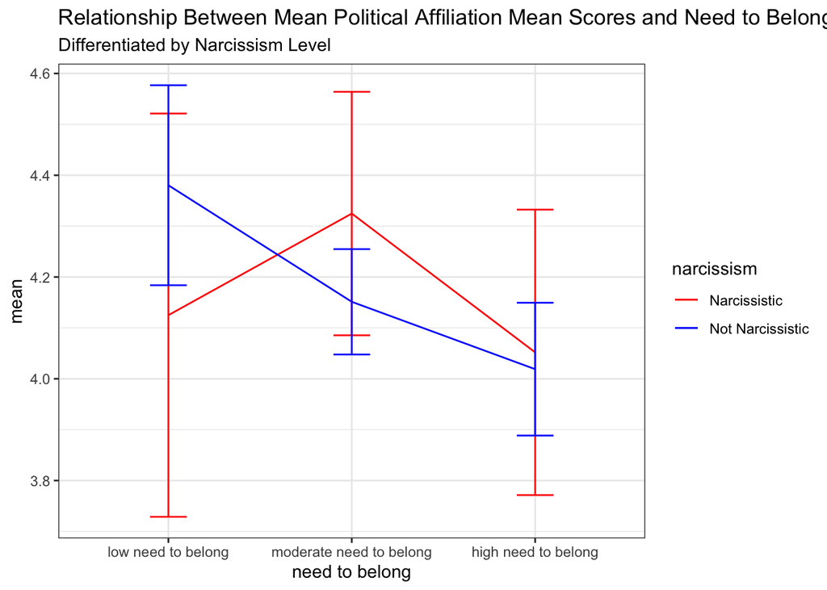

```r
# plotting and visualising the interaction between IV1 and IV2
ggplot(summary_table1, aes(x=factor(need_to_belong, level = c('low need to belong', 'moderate need to belong', 'high need to belong')), y=mean_ratings, group=narcissism, colour=narcissism)) +
  geom_line(stat='identity') +
  geom_errorbar(aes(ymin = CI_95_lower, ymax = CI_95_upper, colour=narcissism), width=0.2) +
  labs(title='Relationship Between Mean Political Affiliation Mean Scores and Need to Belong', subtitle='Differentiated by Narcissism Level', x='need to belong', y='mean') +
  scale_color_manual(labels = c('Narcissistic', 'Not Narcissistic'), values = c('red', 'blue')) +
  theme_bw()
```

There isn’t a clear interaction effect between the need to belong level and their narcissism level; that is, the narcissism factor does not seem to depend on the need to belong factor, and vice-versa.

```r
### STEP 5 - Building the model (two-way ANOVA) ###
model_RQ1 <- ezANOVA(data=data_RQ1,
                     dv=political_affiliation_num,
                     wid=ID,
                     between=c(need_to_belong, narcissism),
                     detailed = TRUE,
                     type=3,
                     return_aov = TRUE)
```

```
## Coefficient covariances computed by hccm()
```

```r
# ANOVA model
datatable(model_RQ1$ANOVA,
          rownames = FALSE,
          caption = htmltools::tags$caption(style ='caption-side: bottom; text-align: center;',
                                            'TABLE 8 - ',
                                            htmltools::em('Output of model_RQ1')
                                            )
          )
```

| Effect | DFn | DFd | SSn | SSd | F | p | p<.05 | ges |
| --- | --- | --- | --- | --- | --- | --- | --- | --- |
| (Intercept) | 1 | 3416 | 27326.2417372584 | 14226.8342459823 | 6561.29397169548 | 0 | * | 0.657622596899437 |
| need_to_belong | 2 | 3416 | 17.6816903604213 | 14226.8342459823 | 2.12277212297797 | 0.119857219631929 |  | 0.00124129808548349 |
| narcissism | 1 | 3416 | 0.103985001505862 | 14226.8342459823 | 0.0249678009177859 | 0.874456660523704 |  | 7.30902178793471e-06 |
| need_to_belong:narcissism | 2 | 3416 | 11.2124524202754 | 14226.8342459823 | 1.34610893770965 | 0.260388959294283 |  | 0.000787499342977532 |

```r
# Levene's Test for Homogeneity of Variance
datatable(model_RQ1$`Levene's Test for Homogeneity of Variance`,
          rownames = FALSE,
          caption = htmltools::tags$caption(style ='caption-side: bottom; text-align: center;',
                                            'TABLE 9 - ',
                                            htmltools::em('Output of Levene\'s Test for model_RQ1')
                                            )
          )
```

| DFn | DFd | SSn | SSd | F | p | p<.05 |
| --- | --- | --- | --- | --- | --- | --- |
| 5 | 3416 | 8.63308978003752 | 4298.06861974656 | 1.37227379540288 | 0.231456066547083 |  |

### Step 6 - Report

Levene’s Test shows that the assumption of homogeneity of variance is met, since it tests for the null hypothesis of homogeneity of variance and we obtained the following, non-significant result (p>.05): F(5, 3416) = 1.37, p = 0.2315.

A two-way between-subjects ANOVA found a non-significant main effect of need to belong level, F(2,3416) = 2.12, p >.05, ges = 0.0012, and of narcissism level, F(1,3416) = 0.03, p>.05, ges = 0.00001, on political affiliation mean scores. The interaction between need to belong level and narcissism level was also non-significant F(2,3416) = 1.35, p>.05, ges = 0.0008.

Therefore, our hypothesis is not supported: neither levels of need to belong nor levels of narcissism are predictors of the political affiliation mean score, both as main effects and as part of an interaction.

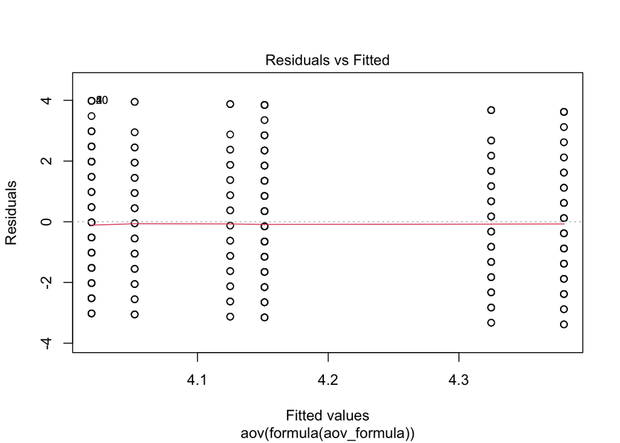

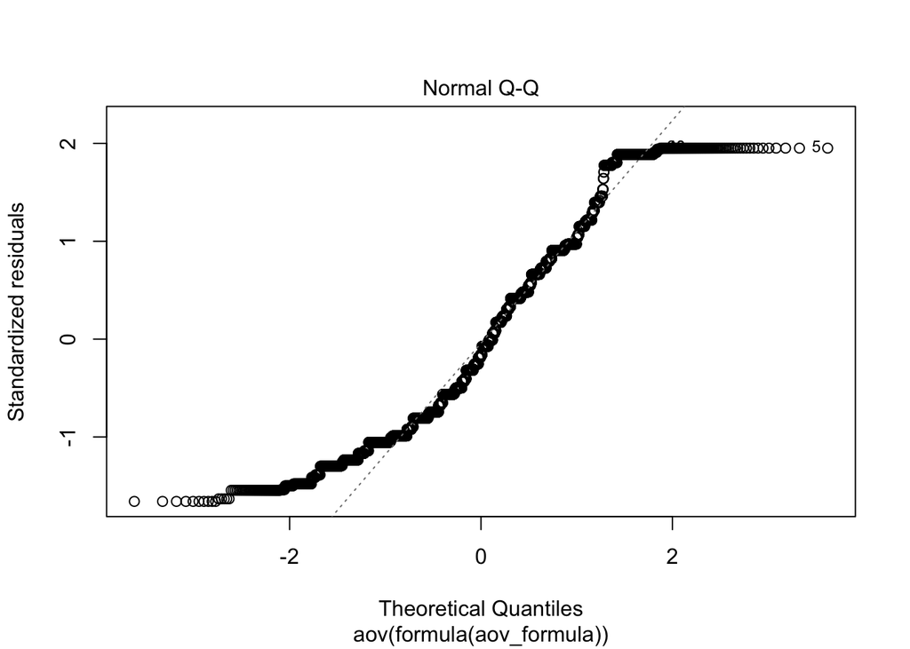

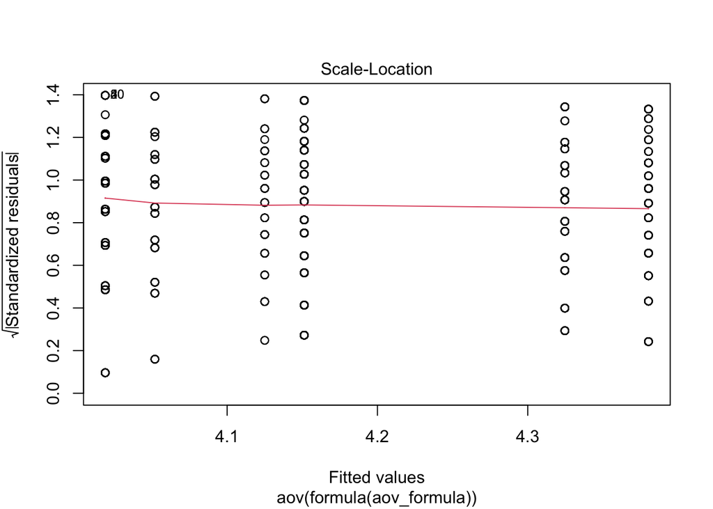

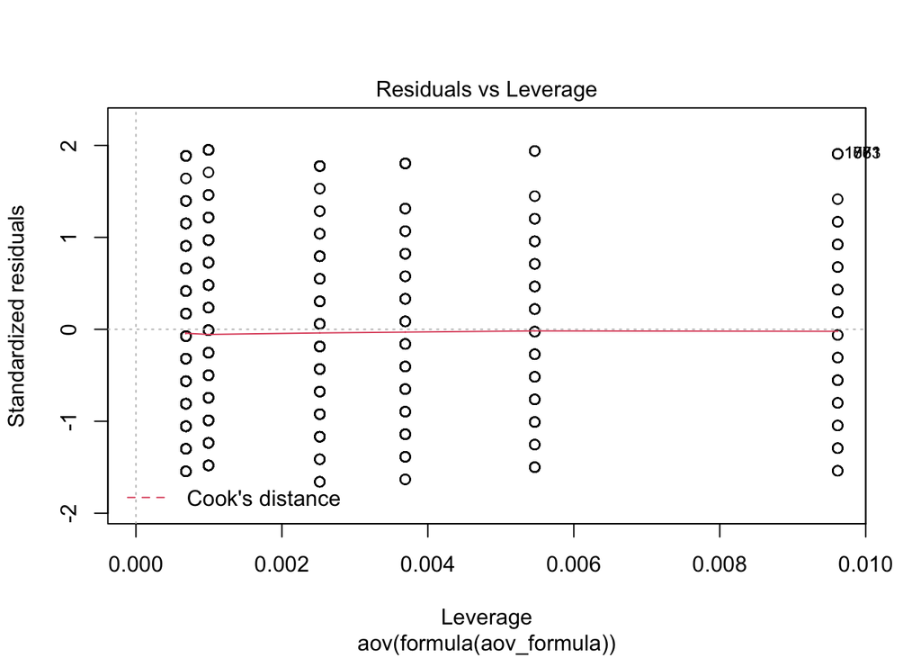

```r
### STEP 7 - Assumption Checking for ANOVA ###

# our DV is ratio level (omitted in the preregistration): OK
# the observations are independent (omitted in the preregistration): OK
# Levene's Test revealed the homogeneity of variance: OK

# We also need to check for the normality of residuals (omitted in the preregistration): QQplot & Shapiro-Wilk Test
plot(model_RQ1$aov) # check 2nd graph: NO
```

```r
# Shapiro-Wilk Normality test (omitted from the preregistration)
# H0: normality of residuals
shapiro.test(model_RQ1$aov$residuals)  # significant, so assumption is NOT met
```

```
##
##  Shapiro-Wilk normality test
##
## data:  model_RQ1$aov$residuals
## W = 0.94468, p-value < 2.2e-16
```

The assumption for the normality of residuals isn’t met (Graph 2 + see above); this is an issue since our groups are also NOT of equal size (see TABLE 6). While acknowledging this limitation, we’ll keep our two-way ANOVA that uses a ‘type 3’ for calculating sum-of-squares (used for unbalanced designs like ours).

## Part 2

> Our second research question follows from Álvarez-Díaz et al.’s study (2010) on the ‘Politics of Happiness’ (described in the preregistration): does political affiliation have an influence on wellbeing, i.e., does one’s political affiliation predict one’s wellbeing on a subjective wellbeing scale?

-**Hypotheses & Model**

Our hypothesis (non-directional) is that there will be a difference in subjective wellbeing mean scores between the various political affiliation groups (groups will be created in STEP 2).

We will conduct a one-way between-subjects ANOVA since we have one categorical independent variable (political affiliation levels) and one numeric dependent variable (subjective wellbeing mean score).

A one-way ANOVA tests the following null hypothesis:

```
  -There is no difference between the political affiliation groups means on the subjective wellbeing scale.
```

We will reject the null hypothesis if p<.05.

-**No recoding required**

```r
### STEP 1 - Preprocessing on the original dataset ###

# creating our numerical DV: subjective_wellbeing
data2 <- data %>% mutate(subjective_wellbeing = (swb_1+swb_2+swb_3+swb_4+swb_5+swb_6) / 6) %>% select(-(swb_1:swb_6))

# we already have our political_affiliation_num variable in data_RQ1, let's add it to data2
data2['political_affiliation_num'] <- data_RQ1 %>% pull(political_affiliation_num)
```

```r
### STEP 2 - Creating Groups (the levels of our categorical IV) ###

# creating categorical political affiliation levels
data2 <- data2 %>% mutate(political_affiliation = case_when(
  between(political_affiliation_num, 1, 3) ~ 'liberal & democrat',
  between(political_affiliation_num, 3.1, 3.9) ~ 'moderate/mixed',
  between(political_affiliation_num, 4, 7) ~ 'conservative & republican',
  between(political_affiliation_num, 7.1, 8) ~ 'apolitical')
)

# NOTE: the pre-registration form has a 'typo': the third level of 'political affiliation' is 'conservative & republican', NOT 'conservative & democrat'
```

```r
### STEP 3 - Dropping some variables/columns ###

# getting rid of temporary variables we used to create our levels of IV (political_affiliation) and other non-relevant variables
data_RQ2 <- data2 %>% select(-politics) %>% select(-party) %>% select(-political_affiliation_num) %>% select(-(belong_1:belong_10)) %>% select(-belnow) %>% select(-(NPI1:NPI13))

# Visualisation of the dataframe relevant to our Research Question 2
datatable(data_RQ2,
          rownames = FALSE,
          colnames = c('Subjective Wellbeing Mean Score', 'Political Affiliation Level'),
          caption = htmltools::tags$caption(style ='caption-side: bottom; text-align: center;',
                                            'TABLE 10 - ',
                                            htmltools::em('Dataframe for Research Question 2')
                                            )
          )
```

|  | Subjective Wellbeing Mean Score | Political Affiliation Level |
| --- | --- | --- |
| 1 | 5 | liberal &amp; democrat |
| 2 | 4 | conservative &amp; republican |
| 3 | 4.5 | liberal &amp; democrat |
| 4 | 4.66666666666667 | liberal &amp; democrat |
| 5 | 1.66666666666667 | apolitical |
| 6 | 6.33333333333333 | conservative &amp; republican |
| 7 | 5.66666666666667 | conservative &amp; republican |
| 8 | 6 | conservative &amp; republican |
| 9 | 6.16666666666667 | conservative &amp; republican |
| 10 | 5.16666666666667 | moderate/mixed |

[output cut: 3412 more lines]

```r
# count of our 4 political affiliation groups
# (unequal sample size across groups)
groups_counttable2 <- data_RQ2 %>% group_by(political_affiliation) %>% summarise(n_respondants=n(),
                                                                                 perct=n_respondants/3422 * 100)
# Visualisation of the count table of groups
datatable(groups_counttable2,
          rownames = FALSE,
          colnames = c('Political Affiliation Level', 'Number of Individuals', 'Proportion (%)'),
          caption = htmltools::tags$caption(style ='caption-side: bottom; text-align: center;',
                                            'TABLE 11 - ',
                                            htmltools::em('Count of Groups (RQ2)')
                                            )
          )
```

| Political Affiliation Level | Number of Individuals | Proportion (%) |
| --- | --- | --- |
| apolitical | 349 | 10.1987142022209 |
| conservative &amp; republican | 1400 | 40.9117475160725 |
| liberal &amp; democrat | 1439 | 42.0514319111631 |
| moderate/mixed | 234 | 6.83810637054354 |

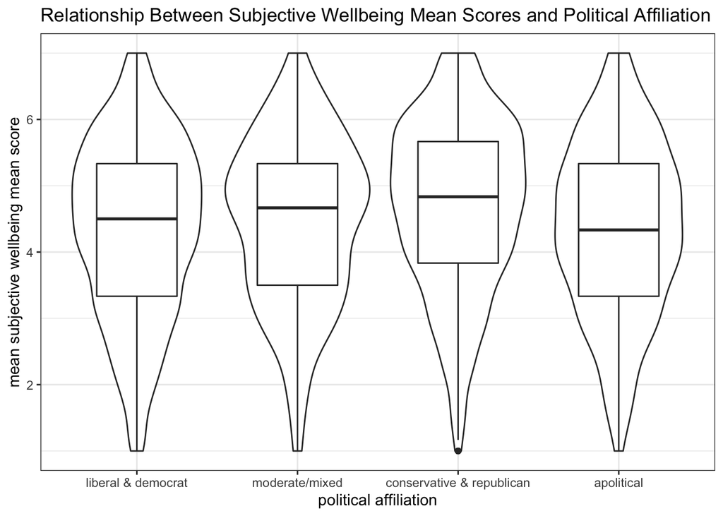

```r
### STEP 4 - Plotting & Visualising our Alternative Hypothesis (H1) ###

# plotting the relationship between our IV (political_affiliation levels) and DV (subjective_wellbeing)
ggplot(data_RQ2, aes(x=factor(political_affiliation, level = c('liberal & democrat', 'moderate/mixed', 'conservative & republican', 'apolitical')), y=subjective_wellbeing)) +
  geom_violin() +
  geom_boxplot(width=0.5) +
  labs(title='Relationship Between Subjective Wellbeing Mean Scores and Political Affiliation', x='political affiliation', y='mean subjective wellbeing mean score') +
  theme_bw()
```

```r
### STEP 5 - Building the model (one-way ANOVA) ###
model_RQ2 <- ezANOVA(data_RQ2,
                     wid = ID,
                     dv = subjective_wellbeing,
                     between = political_affiliation,
                     detailed = TRUE,
                     type=3,
                     return_aov = TRUE)
```

```
## Coefficient covariances computed by hccm()
```

```r
# ANOVA model
datatable(model_RQ2$ANOVA,
          rownames = FALSE,
          caption = htmltools::tags$caption(style ='caption-side: bottom; text-align: center;',
                                            'TABLE 12 - ',
                                            htmltools::em('Output of model_RQ2')
                                            )
          )
```

| Effect | DFn | DFd | SSn | SSd | F | p | p<.05 | ges |
| --- | --- | --- | --- | --- | --- | --- | --- | --- |
| (Intercept) | 1 | 3418 | 37129.3410947848 | 5905.48961620574 | 21489.8503104155 | 0 | * | 0.862774187358484 |
| political_affiliation | 3 | 3418 | 92.4784011979882 | 5905.48961620574 | 17.8416578380062 | 1.73020855480232e-11 | * | 0.0154182884819746 |

```r
# Levene's Test for Homogeneity of Variance
datatable(model_RQ2$`Levene's Test for Homogeneity of Variance`,
          rownames = FALSE,
          caption = htmltools::tags$caption(style ='caption-side: bottom; text-align: center;',
                                            'TABLE 13 - ',
                                            htmltools::em('Output of Levene\'s Test for model_RQ2')
                                            )
          )
```

| DFn | DFd | SSn | SSd | F | p | p<.05 |
| --- | --- | --- | --- | --- | --- | --- |
| 3 | 3418 | 2.00043946545939 | 2070.26614440362 | 1.10090549008614 | 0.347419370935305 |  |

### Step 6 - Report

Levene’s Test shows that the assumption of homogeneity of variance is met since we obtained the following non-significant result (p>.05): F(3, 3418) = 1.10, p = 0.3474.

A one-way between-subjects ANOVA found a significant main effect of political affiliation level, F(3,3418) = 17.84, p<.001, ges = 0.0154, on subjective wellbeing mean scores.

We, thus, found political affiliation to be a statistically significant predictor of the subjective wellbeing mean score: our hypothesis is supported.

We must note that our effect size was only of ges=0.0154, which is a very small effect size, hinting at the presence of a statistical result of lower practical significance.

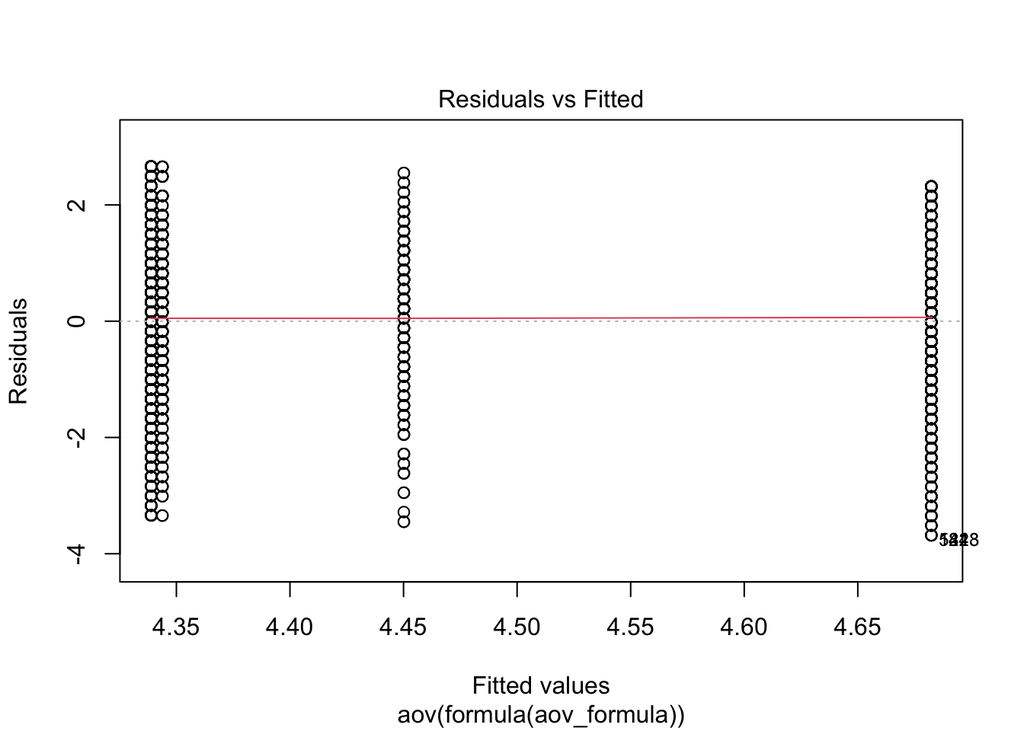

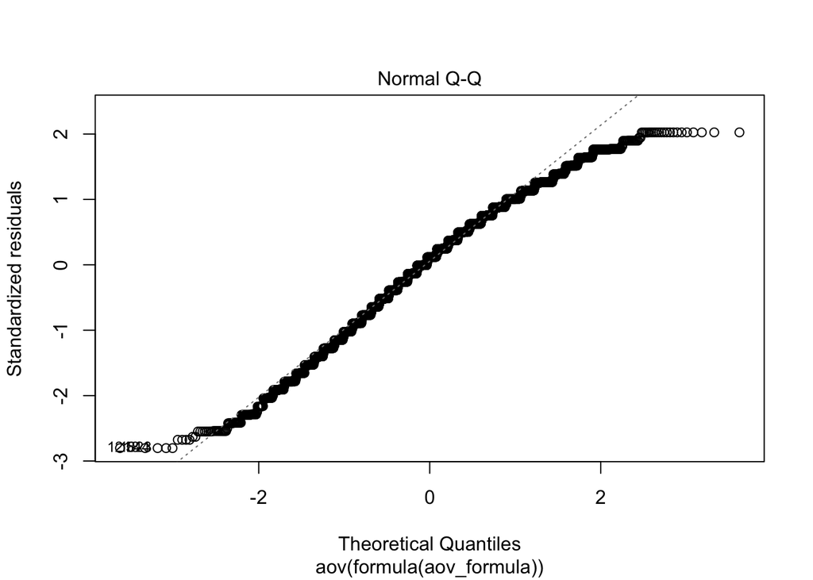

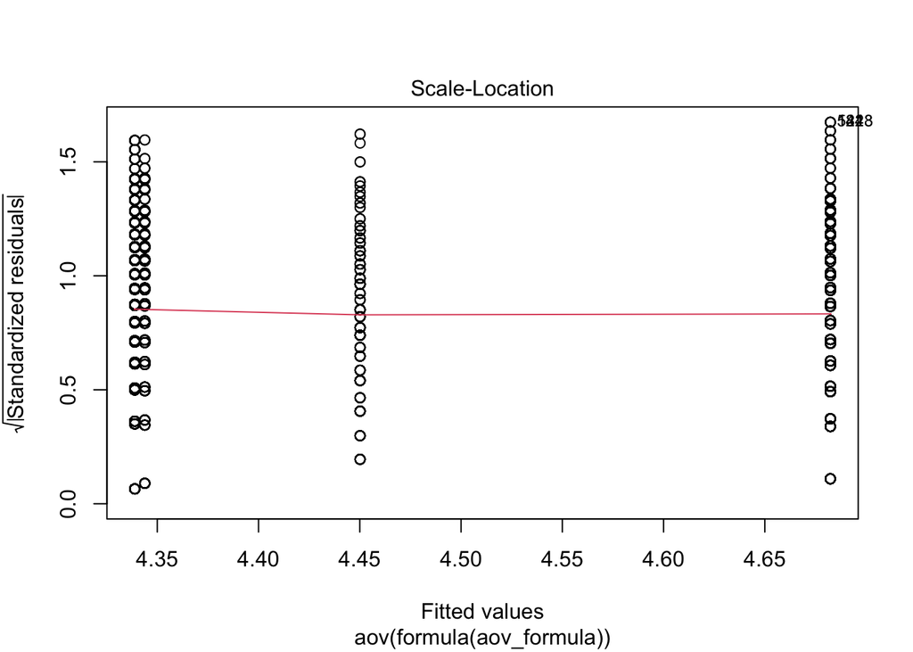

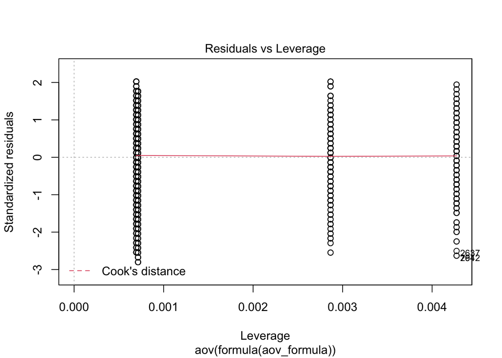

```r
### STEP 7 - Checking assumptions for ANOVAs ###

# our DV is ratio level (omitted in the preregistration): OK
# the observations are independent (omitted in the preregistration): OK
# Levene's Test revealed the homogeneity of variance: OK

# We also need to check for the normality of residuals (omitted in the preregistration)
plot(model_RQ2$aov) # check 2nd graph: NO
```

```r
# Shapiro-Wilk Normality test (omitted from the preregistration)
# H0: normality of residuals
shapiro.test(model_RQ2$aov$residuals)  # significant, so assumption is NOT met
```

```
##
##  Shapiro-Wilk normality test
##
## data:  model_RQ2$aov$residuals
## W = 0.98395, p-value < 2.2e-16
```

Residuals aren’t normally distributed (Graph 2 + see above); we will run a Kruskal–Wallis test, the non-parametric equivalent of a one-way ANOVA, robust to non-normality of residuals. The preregistration omitted the likelihood of this scenario.

```r
# running the Kruskal-Wallis one-way analysis of variance
kruskal.test(subjective_wellbeing ~ political_affiliation, data=data_RQ2)
```

```
##
##  Kruskal-Wallis rank sum test
##
## data:  subjective_wellbeing by political_affiliation
## Kruskal-Wallis chi-squared = 52.219, df = 3, p-value = 2.69e-11
```

A Kruskal-Wallis test revealed, like our one-way ANOVA, a significant main effect of political affiliation level on subjective wellbeing mean scores: H(3) = 52.22, p<.001, supporting our non-directional hypothesis.

```r
### STEP 8 - Post-Hoc t-tests ###

# We will now run two-sample t-tests to run pairwise comparisions between the different political affiliation groups. The description of these statistical analysis has been omitted in the preregistration: these post-hoc t-tests are required to gain insight into the 'meaning' of our significant predictor relationship, i.e. what groups actually differ in subjective wellbeing mean scores?

# To do these pairwise comparisons easily and to apply Bonferroni correction to the p-values, we will use emmeans()
mod_pairwise_RQ2 <-emmeans(model_RQ2$aov, pairwise ~ political_affiliation, adjust = "bonferroni")

mod_contrasts_RQ2 <- mod_pairwise_RQ2$contrasts %>% tidy()

datatable(mod_contrasts_RQ2,
          rownames = FALSE,
          caption = htmltools::tags$caption(style ='caption-side: bottom; text-align: center;',
                                            'TABLE 14 - ',
                                            htmltools::em('Pairwise Comparisons of Political Affiliation Groups (model_RQ2)')
                                            )
          )
```

| term | contrast | null.value | estimate | std.error | df | statistic | adj.p.value |
| --- | --- | --- | --- | --- | --- | --- | --- |
| political_affiliation | apolitical - conservative &amp; republican | 0 | -0.338541410833669 | 0.0786430049133586 | 3418 | -4.30478732605197 | 0.000103102460315039 |
| political_affiliation | apolitical - liberal &amp; democrat | 0 | 0.00494679195265822 | 0.0784300645952743 | 3418 | 0.0630726492217664 | 1 |
| political_affiliation | apolitical - (moderate/mixed) | 0 | -0.106302908595168 | 0.111059460925871 | 3418 | -0.957171119947375 | 1 |
| political_affiliation | conservative &amp; republican - liberal &amp; democrat | 0 | 0.343488202786327 | 0.049343529090587 | 3418 | 6.96116003692676 | 2.41726247769716e-11 |
| political_affiliation | conservative &amp; republican - (moderate/mixed) | 0 | 0.232238502238501 | 0.0928316362660909 | 3418 | 2.50171721171452 | 0.074433932600646 |
| political_affiliation | liberal &amp; democrat - (moderate/mixed) | 0 | -0.111249700547826 | 0.0926513113909121 | 3418 | -1.2007353039877 | 1 |

Two two-sample t-tests revealed significant differences: the ‘conservative & republican’ group has a significantly higher mean subjective wellbeing mean score than the ‘liberal & democrat’ group (+0.34): t(3418) = 7.0, adjusted p <.001; the ‘apolitical’ group has a significantly lower mean subjective wellbeing mean score than the ‘conservative & republican’ group (-0.34): t(3418) = -4.3, p <.001.

## Extra: Some Considerations

[output not shown]

## References

Álvarez-Díaz, Á., González, L., & Radcliff, B. (2010). The Politics of Happiness: On the Political Determinants of Quality of Life in the American States. The Journal of Politics, 72(3), 894-905.

Dumas, Tara M, Maxwell-Smith, Matthew, Davis, Jordan P, & Giulietti, Paul A. (2017). Lying or longing for likes? Narcissism, peer belonging, loneliness and normative versus deceptive like-seeking on Instagram in emerging adulthood. Computers in Human Behavior, 71, 1-10.

Greene, S. (2004). Social Identity Theory and Party Identification. Social Science Quarterly, 85(1), 136-153.

Smith, J. L. (2013). Reducing narcissistic defensiveness through the activation of belonging.